# Fonctionnement du WEB

## Introduction

Le mot WEB est une abréviation de l'expression **World Wide WEB** qui signifie *toile d'araignée de taille mondiale*.

Le principe du WEB consiste à relier des documents entre eux via des liens hytpertextes. Un **lien hypertexte** est un mot, une phrase ou une image qui permet d'accéder au document vers lequel il renvoie.

Pour afficher et lire un document du WEB, on utilise un logiciel appelé **navigateur**. Il en existe de nombreux comme FIREFOX, CHROME, EDGE, OPERA,...

Différents langages sont utilisés pour structurer et afficher les documents du WEB :

- Le langage HTML qui est compose, structure le contenu du document à afficher par le navigateur,
- Le langage CSS qui assure la mise en page et l'apparence graphique du document,
- Le langage JAVASCRIPT qui permet d'ajouter de l'interactivité au document.

## Le langage HTML

HTML est l'acronyme de **Hyper Text Markup Language** signifiant Langage de Balisage Hyper Texte.

Le Langage HTML est un fichier texte, avec l'extension html, qui est composé du contenu à afficher et de la structure du document selon laquelle le contenu est organisé : titre, paragraphe, emphase, liste, lien, image, etc.

### Les balises

La structure du document est décrite par des balises, qui sont des mots délimités par les caractères $<$ et $>$ appelés *chevrons*. On a 2 types de balises:

- Les balises **ouvrantes** et **fermantes**: `<balise>`contenu`</balise>`. Par exemple: `<p>`le contenu d'un paragraphe`</p>`.
- Les balises **vides** : `<balise />`. Par exemple, l'insertion d'une image se fait avec la balise `<img src="chemin_vers_le_fichier.jpg" />`.

Les balises les plus fréquentes dans un document HTML sont :

- le titre : `<h1>titre</h1>`
- les sous-titres : `<h2>sous-titre de niveau 2</h2>` jusqu'à `<h6>sous-titre de niveau 6</h6>`
- les paragraphes : `<p>le contenu du paragraphe</p>`
- l'italique : `<i>mot en italique</i>`
- le gras : `<b>un mot en gras</b>`
- l'emphase (italique ou gras) : `<em>un mot en italique ou en gras</em>`
- les images : `<img src="..." />`
- les liens hypertextes : `<a href="...">le lien</a>`
- les listes numérotées : `<ol>...</ol>` et à l'intérieur `<li>...</li>` autant de fois que de numéros.
- les listes à puces : `<ul>...</ul>` et à l'intérieur `<li>...</li>` autant de fois que de numéros.

### Les attributs

Les balises peuvent contenir des **attributs** qui sont des propriétés à appliquer au contenu à afficher.

Certaines balises ont nécessairement au moins un attribut. C'est le cas des balises images qui doivent avoir le nom du fichier image à afficher. La balise est **src**. C'est aussi vrai pour la balise de lien hypertexte qui doit avoir l'url de la page associée au lien. L'attribut est **href**.

D'autre attributs peuvent être ajoutés aux balises. On retrouve par exemple:

- l'attribut `title` qui est un texte associé à un lien hypertexte,
- l'attribut `alt` qui est un texte alternatif à une image non trouvée,
- l'attribut `width` ou `height` qui impose une largeur ou une hauteur à l'image.

### Structure d'un document HTML

Les documents HTML ont la même structure (squelette) générale.

- Déclaration de type nécessaire au navigateur pour savoir que c'est un document HTML: `<!Doctype html>`
- Tout le document HTML est inséré entre les balises `<html>` et `</html>`.
- Ensuite, le document HTML se décompose en 2 parties avec les balises `<head></head>` constituant l'en-tête du document et les balises `<body></body>` contenant le corps du document c'est à dire le contenu à afficher.

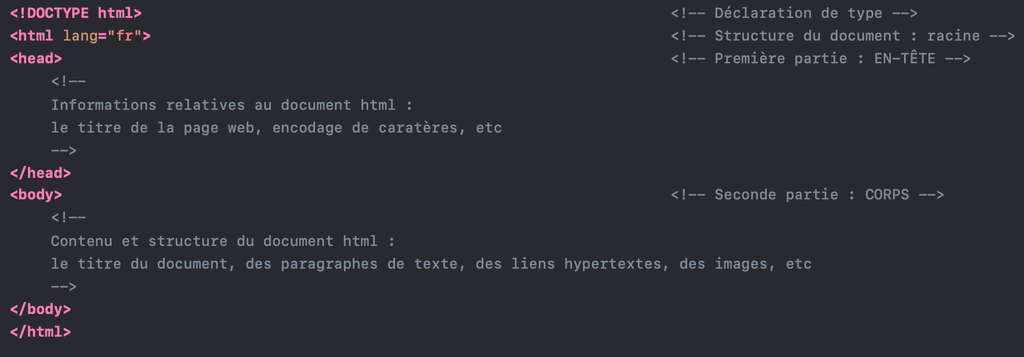

### L'en-tête du document HTML

Voici un exemple d'en-tête de document HTML:

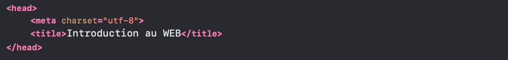

### Le corps du document HTML

Le corps `<body>...</body>` contient le contenu et la structure du document. On peut distinguer différents types de balises :

- Les balises de structure comme le titre, les sous-titres, les paragraphes, une liste, un tableau, etc.
- Les balises de mise en forme de texte comme le gras, l'italique, l'exposant, l'indice,
- Les balises de contenus comme le lien hypertexte, l'image ou tout autre média.

Voici un exemple de corps de document HTML qui contient:

- un titre principal de niveau 1 `<h1>`,
- deux paragraphes `<p>`,
- une liste numérotées avec 2 items (1 et 2) `<ol>` et `<li>`

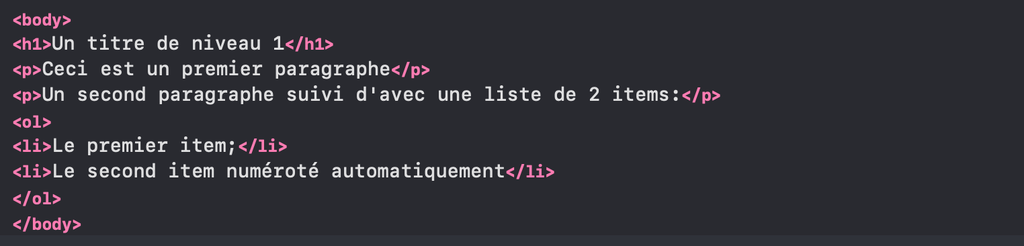

Le code HTML précédent donnera le document suivant affiché par un navigateur:

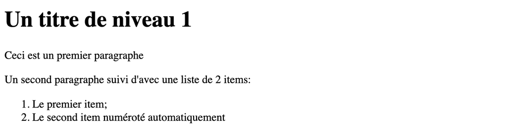

### Exemple de document HTML complet

Le code et la page html contiennent un titre, 3 paragraphes, un mot en gras, au autre en italique, des exposants, une image et un lien hypertexte.

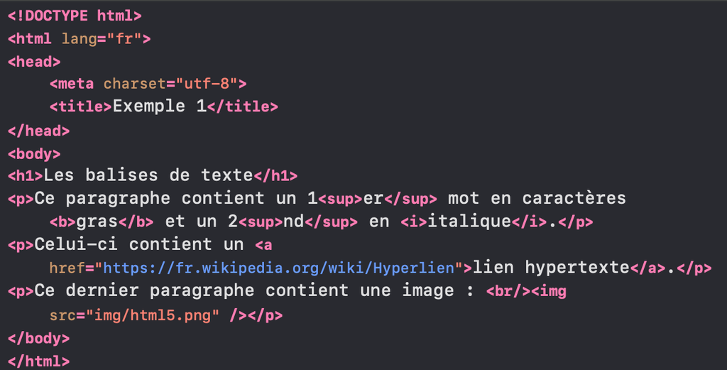

[figure not shown]

## Le langage CSS

Le langage CSS de l'anglais **Cascading Style Sheets** signifiant feuilles de style en cascade est un langage permettant de définir les propriétés graphiques des éléments HTML constituant une page Web. Cela permet par exemple :

- De modifier la police de caractère, sa taille, sa fonte, son alignement, sa couleur etc.
- De modifier les couleurs des différents éléments HTML de la page comme les fonds.
- De gérer les espacements entre les blocs et leurs dispositions.
- D'ajouter des images de fond et des logos.

L'application d'un **style CSS** se fait par le choix d'un **sélecteur** contenant, entre deux accolades, des couples `propriétés:valeurs` séparés par des points virgules

Le nombre de propriétés dans un sélecteur n'est pas limité tant qu'elles existent:

```
selecteur {
    propriete1 : valeur;
    propriete2 : valeur;
    propriete3 : valeur;
}
```

L'application de règles CSS dans un document HTML se fait en ajoutant dans la balise `<head>` du document html la balise `<style>`. Cette balise a un attribut `type` qui précise que c'est du CSS.

```
<head>
    <title>Fonctionnement du web</title>
    <meta charset="UTF-8" />
    <style type="text/css">
        selecteur1{...}
        selecteur2{...}
        ...
    </style>
</head>
```

### Exemple de document HTML avec style CSS

Voici le corps (body) d'un document en HTML:

```
<body>
    <h1>Un titre en noir</h1>
    <p>Mon premier paragraphe est court mais montre l'étendue des règles CSS.</p>
</body>
```

Ce document HTML sera affiché :

# Un titre en noir

Mon premier paragraphe est court mais montre l'étendue des règles CSS.

Voici des règles CSS associées aux sélecteurs de titre `<h1>` et de paragraphe `<p>`.

```
<style type="text/css">
        h1{
            color:red;
            padding:10px;
        }
        p{
            text-align:right;
            border: solid 1px #0000ff;
        }
    </style>
```

Après application des règles CSS:

- titre en rouge, plus espacé (padding)
- paragraphe aligné à droite et encadré en bleu

la page sera affichée de la façon suivante:

# Un titre en noir

Mon premier paragraphe est court mais montre l'étendue des règles CSS.

### Les sélecteurs CSS

Il existe plusieurs manières de choisir un **sélecteur** en CSS. On vient de voir qu'on peut utiliser directement la balise html du document comme dans l'exemple précédent.

Cette méthode est simple mais rencontre une difficulté. Les règles CSS seront appliquées à tous les sélecteurs de même type. Dans l'exemple précédent, s'il y avait plusieurs paragraphes, ils seraient tous alignés à droite et encadrés en bleu !

# Un titre en noir

Mon premier paragraphe est court mais montre l'étendue des règles CSS.

Un second paragraphe aligné à droite et encadré en bleu alors qu'il n'a rien demandé à personne!

Pour y remédier, on ajoute un **attribut** `class` à la balise HTML. Cette méthode offre 2 avantages:

1. Des balises différentes avec la même classe ont les mêmes règles CSS appliquées. Par exemple un paragraphe `<p>` et un titre de niveau 2 `<h2>`
2. Des balises identiques peuvent avoir des règles CSS différentes en leur attribuant des classes différentes.

Reprenons l'exemple précédent avec un second paragraphe. On ajoute aux balises de paragraphes l'attribut `class` et pour chacun une classe différente: `rouge-droit` et `vert-centre`.

```
<body>
    <h1>Un titre en noir</h1>
    <p class="rouge-droite">Mon premier paragraphe est court mais montre l'étendue des règles CSS.</p>
    <p class="vert-centre">Un second paragraphe ravi d'être différent du premier!</p>
</body>
```

Dans les règles de style, on définit les propriétés CSS de nos deux classes en les faisant précéder d'un point:

```
h1{
        color:red;
        padding:10px;
    }
    .rouge-droit{
        text-align:right;
        border: solid 1px #0000ff;
    }
    .vert-centre{
        text-align:center;
        border: solid 1px #00ff00;
    }
```

Ce document HTML sera affiché :

# Un titre en noir

Mon premier paragraphe est court mais montre l'étendue des règles CSS.

Un second paragraphe ravi d'être différent du premier!

## Feuille de style CSS

Nous avons vu que l'on peut ajouter des règles CSS à un document HTML avec la balise `<style>` placé entre les balises `<head>` et `</head>`.

Cette méthode est simple puisque tout est réuni dans un même fichier html. Mais elle rencontre un problème. Si je dois écrire plusieurs documents html avec les mêmes règles de style, je suis contraint d'écrire mes règles CSS dans chaque document HTML. Le copier-coller est fastidieux mais possible. Mais que se passe-t-il si je dois changer la couleur d'un titre ? Pas d'autre choix que de modifier tous les documents html!

Heureusement, on peut résoudre facilement cet inconvénient. Il suffit de rassembler les règles CSS dans un même fichier avec l'extension CSS et ajouter dans les documents html un lien vers cette feuille de style. Du coup, si je dois changer la couleur d'un titre, je n'ai qu'un seul fichier et une seule propriété CSS à modifier.

### Exemple de feuille de style externe

1. On crée un fichier avec toutes les règles CSS et on enregistre ce fichier avec une extension **css**, par exemple `mon_style.css`.

   ```
   h1{
        color:red;
        padding:10px;
    }
    .rouge-droit{
        text-align:right;
        border: solid 1px #0000ff;
    }
    .vert-centre{
        text-align:center;
        border: solid 1px #00ff00;
    }
   ```

2. On ajoute dans les documents html la balise : `<link type="text/css" href="chemin_vers_css/mon_style.css" rel="stylesheet" />`. Ici, le document HTML est dans le même dossier que la feuille de style.

   ```
   <head>
    <title>Fonctionnement du web</title>
    <meta charset="UTF-8" />
    <link type="text/css" href="mon_style.css" rel="stylesheet" />
   </head>
   <body>
    <h1>Un titre en noir</h1>
    <p class="rouge-droite">Mon premier paragraphe est court mais montre l'étendue des règles CSS.</p>
    <p class="vert-centre">Un second paragraphe ravi d'être différent du premier!</p>
   </body>
   ```

## Le Langage JAVASCRIPT

### Présentation

Le langage JAVASCRIPT a été créé par Brendan Eich en 1985 pour permettre aux navigateurs (FIREFOX, CHROME, ...) d'exécuter des programmes pour les documents WEB.

- JAVASCRIPT est un un langage de programmation avec des variables (numériques, chaines de caractères, tableaux,...), des conditions (if ... else), des boucles et des fonctions;
- JAVASCRIPT permet de modifier le document HTML et les règles CSS du document;
- JAVASCRIPT est à l'écoute d'événements qui sont liés aux actions du lecteur du document HTML : click de souris, déplacement de la souris, pression sur touche du clavier, chargement d'un document, ...

Un script JAVASCRIPT se déclare avec la balise `<script>` située dans le `<head>` du document HTML. Il existe deux méthodes pour charger un script JAVASCRIPT:

1. le script JAVASCRIPT est écrit entre les balises `<script>` et `</script>` dans le document HTML.
2. le script JAVASCRIPT est écrit dans un fichier externe d'extension JS et appelé par la balise `<script src="js/monscript.js" type="text/javascript"></script>`.

### Document Object Model (DOM)

Un document HTML est constitué de différents éléments html imbriqués les uns dans les autres. Cette structure peut se représenter par un arbre dont les noeuds sont les éléments html (balises) et reliés entre eux par des branches. Cette structure s'appelle le DOM pour Document Object Model.

Voici le code HTML d'une page WEB et son DOM:

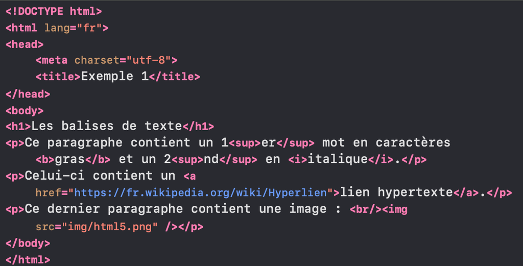

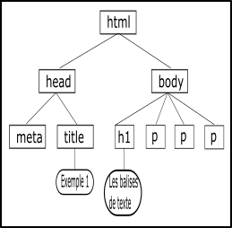

Chaque noeud du DOM possède des propriétés et notamment le contenu s'il en a un. Par exemple, le titre `<h1>` a une propriété `content` qui a pour valeur `Les balises de texte`. Il a d'autres propriétés comme les propriétés CSS, il a aussi des parents, des frères, des fils, etc. comme dans un argre généalogique.

Chaque noeud est un **objet** JAVASCRIPT que l'on peut manipuler, modifier, supprimer, duppliquer avec ce langage.

Pour accéder à un noeud du DOM (balise html), on lui ajoute un attribut `id` qui permet de l'identifier de manière unique.

Pour modifier un noeud du document HTML, on utilise la méthode JAVASCRIPT `getElementById("id_de_la_balise")` du document qui permet d'accéder directement à la balise que l'on souhaite modifier. Par exemple pour modifier la couleur d'un titre `<h1>`:

```
<h1 id="titre">Mon titre</h1>
```

# Mon titre

On peut écrire le script JAVASCRIPT suivant:

[output not shown]

# Mon titre

### Les événements JAVASCRIPT

JAVASCRIPT comme beaucoup de langages de programmation permet d'écrire des fonctions. La syntaxe est la suivante:

```
function ma_fonction(){
    instructions
}
```

Si on écrit des fonctions JAVASCRIPT, on peut les exécuter à des moments biens choisis, selon l'interaction du lecteur de la page WEB. Lorsque le lecteur déplace la souris ou lorsqu'il clique sur un élément de la page, il crée de l'interaction. On appelle ces interactions des **événements**.

JAVASCRIPT est à l'écoute des événements. Il est capable d'identifier un clic de souris ou le survol d'un élément de la page. Lorsqu'un événement se produit, on peut exécuter une fonction JAVASCRIPT.

Par exemple, on peut changer la couleur d'un titre en le survolant avec la souris. Il faut identifier l'événement et écrire une fonction qui change la couleur.

1. L'événement JAVASCRIPT est `onmouseover`, c'est un attribut à placer sur la balise de titre.
2. La fonction JAVASCRIPT est `changeCouleur()` qui change la couleur du titre repéré par un identifiant.

Code de la fonction JAVASCRIPT:

```
<script type="text/javascript">
        function changeCouleur(){
            document.getElementById('titre').style.color = 'blue';
        }
    </script>
```

Code du document HTML

```
<h1 id="titre" onmouseover="changeCouleur()">Mon titre</h1>
```

# Mon titre

Vous pouvez survoler le titre!